# MOTIVAZIONI E DOMANDE DEL PROGETTO

## Motivazioni

- Comprendere le preferenze dei consumatori nel settore dei veicoli
- Individuare le variabili che influenzano il prezzo dei veicoli

# MOTIVAZIONI E DOMANDE DEL PROGETTO

## Domande

- Quali sono i marchi più venduti? Quanto costano in media? Da che paesi provengono?
- I veicoli con più chilometri costano di meno?
- I veicoli con cilindrata maggiore costano di più?
- Il prezzo è influenzato dal numero di posti?
- Quali sono le preferenze dei consumatori riguardo al tipo di carrozzeria, cambio e carburante?

# I DATI UTILIZZATI

- I dati sono stati estratti da autotrader.com, un sito di compravendita di veicoli nuovi e usati
- I dati riguardano l'Australia
- Il dataset fornisce informazioni base come modello, chilometri e specifiche tecniche
- Il dataset è stato pubblicato su [Kaggle](https://www.kaggle.com/datasets/lainguyn123/australia-car-market-data/data) il 3 settembre 2024

## Quali sono i marchi più venduti?

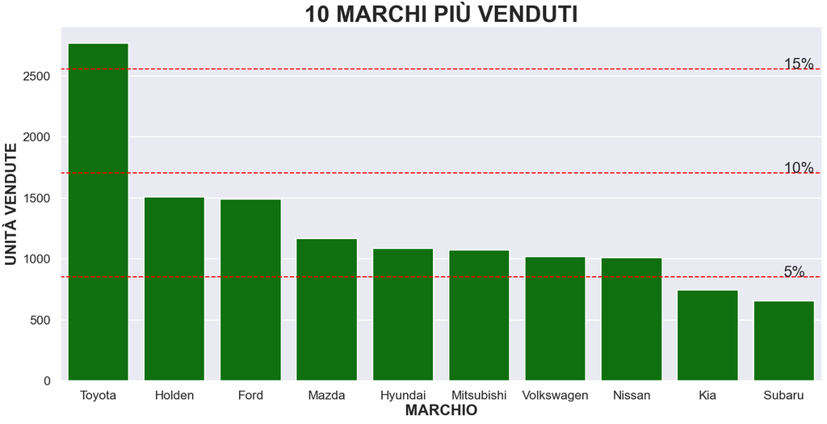

## Quanto costano?

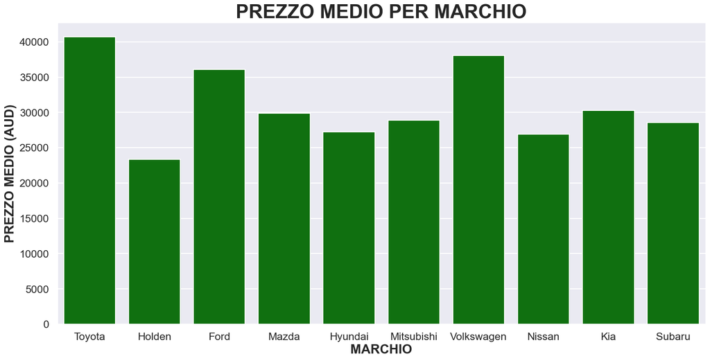

## Da che paesi provengono?

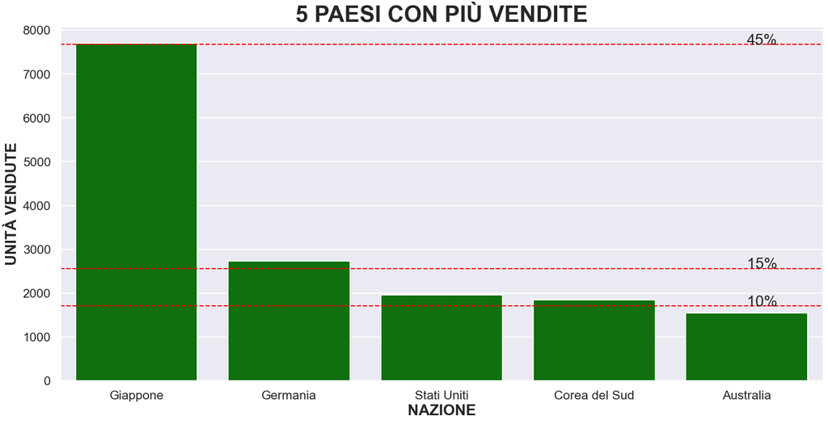

## I veicoli con più chilometri costano meno?

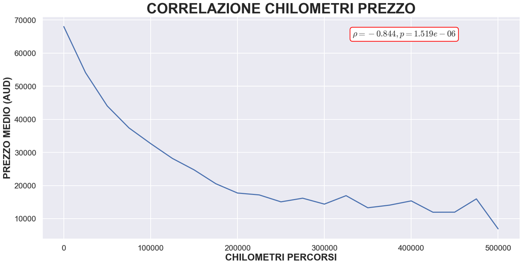

## I veicoli con una cilindrata maggiore costano di più?

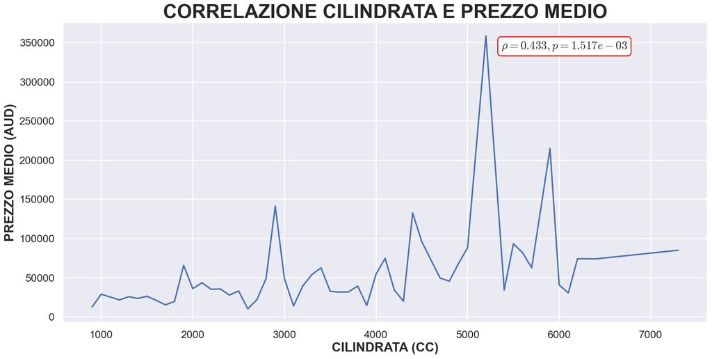

## Il numero di posti influenza il prezzo?

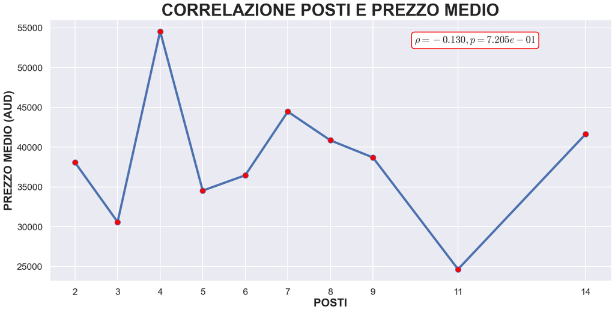

## Quali sono le preferenze relativamente alla carrozzeria?

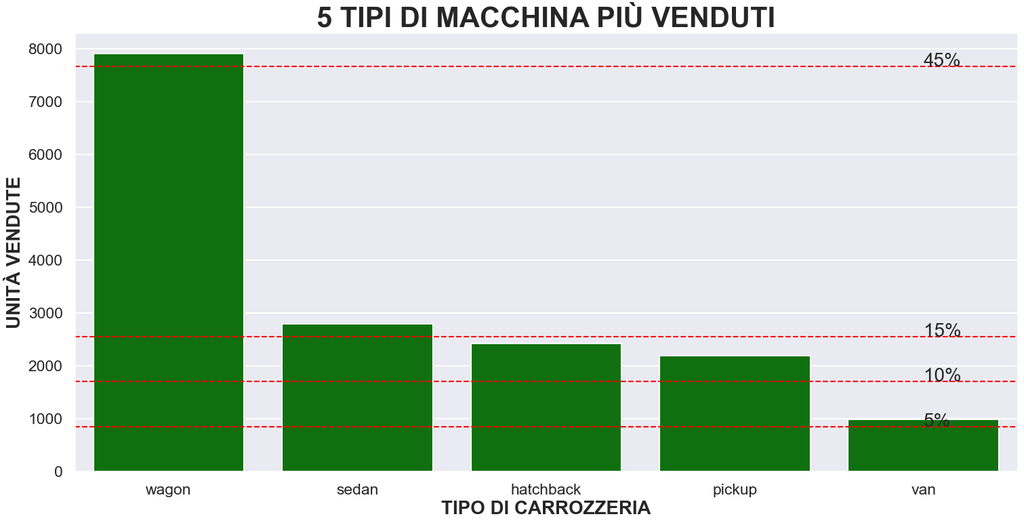

## Quali sono le preferenze relativamente al cambio?

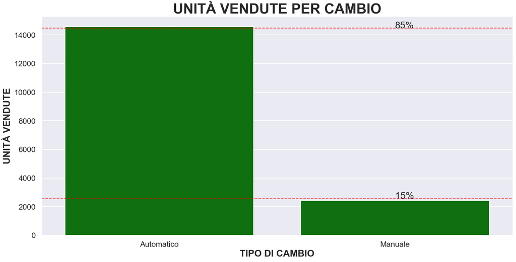

## Quali sono le preferenze relativamente al carburante?

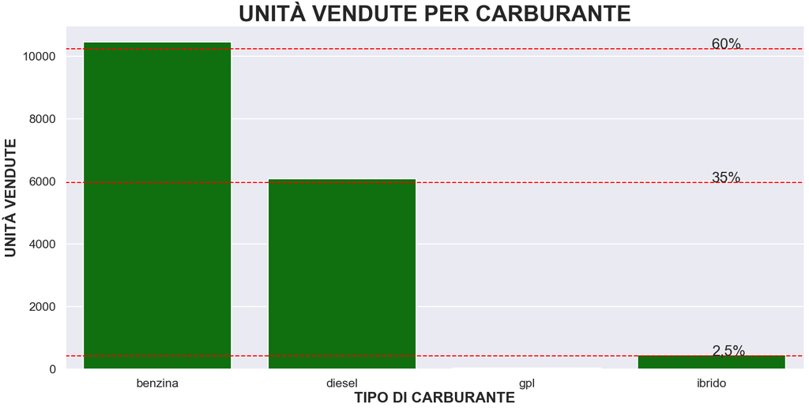

# Conclusioni

- Marchi più venduti: Toyota(16%), Holden(8,8%) e Ford(8,7%)
- Provenienza: Giappone(45%), Germania(16%), USA(11%)
- Le macchine con più chilometri tendono a costare meno
- Le macchine con una cilindrata maggiore tendono a costare di più
- Nessuna tendenza chiara tra prezzo e numero di posti
- Carrozzeria preferita: wagon(46%), sedan(16%), hatchback(14%)
- L'automatico(86%) viene preferito rispetto al manuale(14%)
- Carburante: benzina(61%), diesel(36%), ibrido(3%) e gpl